# Final Project

Lakna Perera

10/4/2021

### **Reported cases as a percentage of total population**

```r
cases_deaths_world <- covnat_weekly
df1 <- cases_deaths_world %>%
  filter(date == max(date), !is.na(pop)) %>%
  mutate(pop_percentage_cases = round((cu_cases/pop)*100, digits = 2),
         mytext = paste("Country: ", cname, "\n",
                        "Percentage: ", pop_percentage_cases, "%", sep=""))

plot_ly(df1, type='choropleth',
        locations=df1$iso3,
        z=df1$pop_percentage_cases,
        text = df1$mytext,
        colorscale= "#de2d26") %>%
        layout(title = "Percentage of Reported Covid-19 Cases")
```

[interactive chart not shown]

### Interpretation

- Generally, the number of reported Covid-19 cases for each country is relative to the population of the respective country. Therefore, it is insightful to analyse the reported cases relative to the total population of each country.
- This graph shows Covid-19 reported cases as a percentage to the total population of different countries in the world.
- The percentage of infected people varies between zero and 20.01%.
- The maximum percentage is recorded as Seychelles with a value of 20.01%.
- Higher percentages are indicated by darker colors.
- Percentage of reported Covid-19 cases for USA is recorded as 11.39%.
- Percentage of reported Covid-19 cases is lower in Sri Lanka compared to the other countries.
- However, countries such as Micronesia, Samoa, Soloman Islands and Vanuatu with zero cases of Covid-19 may not indicate that there is no Covid-19 cases in those countries. This may be due to lack of Covid-19 screening tests done in those countries.

### **Statewise analysis of reported Covid-19 cases in USA**

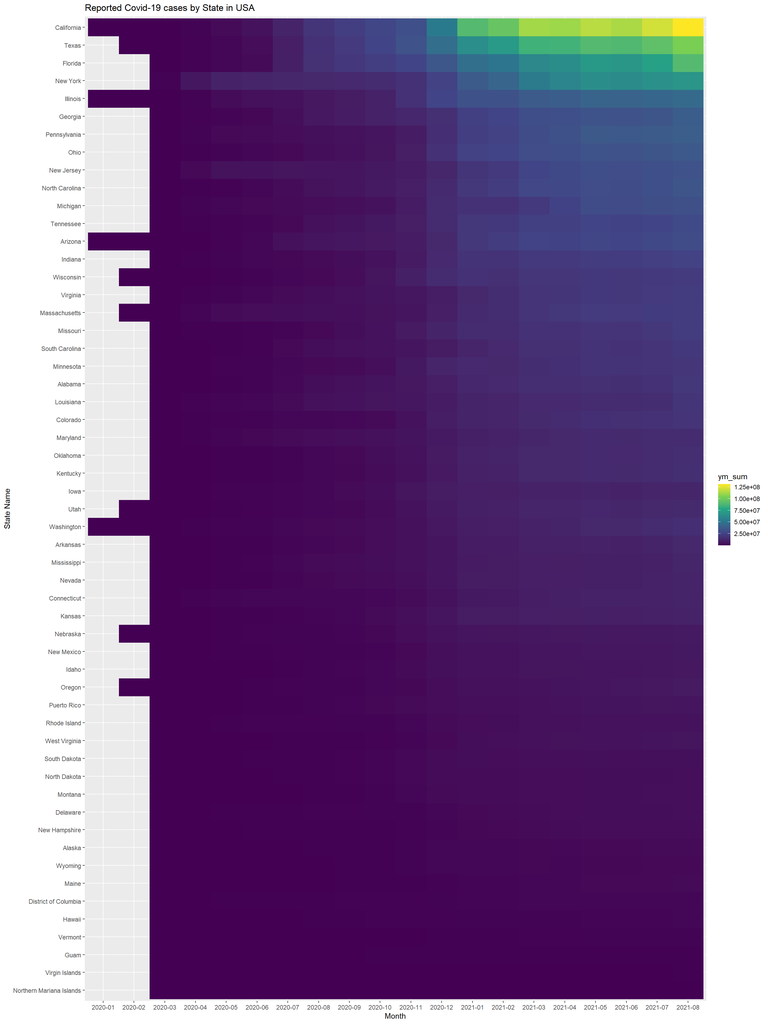

```r
df4 <- nytcovcounty

df4 %>%
  mutate(ym = format(date, '%Y-%m')) %>%
  group_by(ym, state) %>%
  summarize(ym_sum = sum(cases)) %>%

  ggplot(aes(x = ym, fill = ym_sum, y = reorder(state,ym_sum))) +
   geom_raster()+
   scale_fill_viridis_c() +
   ggtitle("Reported Covid-19 cases by State in USA") +
   labs(x = "Month", y = "State Name")
```

### Interpretation

- This graph shows reported Covid-19 cases aggregated monthly for each state in USA.
- In January 2020 only California, Illinois, Arizona and Washington had reported Covid-19 cases.
- In February another six states namely Texas, Wisconsin, Massachusetts, Utah, Nebraska and Oregon were reported with Covid-19 cases.
- From March 2020 the Covid-19 virus started to spread in almost every state in USA.
- California is reported as the state with highest cases of Covid-19 followed by Texas, Florida and New York respectively.
- The reported cases in the period 2020 December to 2021 August are comparatively higher.
- The highest Covid-19 cases were also reported in California in August 2021.

### **Analysis of Covid-19 deaths by age in USA**

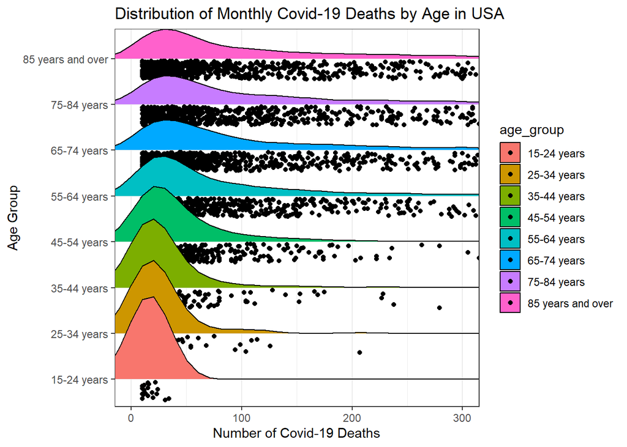

```r
df2 <- nchs_sas

age_group_names <- c("Under 1 year","1-4 years","5-14 years","15-24 years",
                     "25-34 years","35-44 years","45-54 years","55-64 years",
                     "65-74 years","75-84 years","85 years and over")

selected_data <- df2 %>%
  filter(group == "By Month",
         sex == "All Sexes",
         age_group %in% age_group_names,
         state != "United States")  # Remove data stored
                                    # as United States (repeated values)

# Assign zero to missing values in covid-19 deaths
selected_data$covid_19_deaths[is.na(selected_data$covid_19_deaths)] <- 0

selected_data %>%
  filter(covid_19_deaths > 0) %>%
  mutate(age_group = as.factor(age_group)) %>%
  ggplot(aes(x = covid_19_deaths,
             y = age_group,
             fill = age_group)) +
   geom_density_ridges(position = "raincloud",
                      jittered_points = TRUE) +
   coord_cartesian(xlim = c(0, 300)) +
   labs(title = "Distribution of Monthly Covid-19 Deaths by Age in USA",
       x = "Number of Covid-19 Deaths",
       y = "Age Group") +
   theme_bw()
```

### Interpretation

- This graph shows reported Covid-19 deaths aggregated monthly under each age category in USA.
- There were no reported Covid-19 deaths below the age of 15.
- Most of the monthly death counts are within the range of 1 - 100 for every age group.
- The variance of the reported monthly death counts is increasing with the age. For an instance Covid-19 deaths in the age group 15 -24 vary between 1 to 50 but for the people who are aged 85 and above has reported monthly deaths over 300.
- Also this graph clearly shows that age is a critical parameter which determines the deaths due to Covid-19.

### **Analysis of reported Covid-19 deaths, Pneumonia deaths and Influenza deaths in USA**

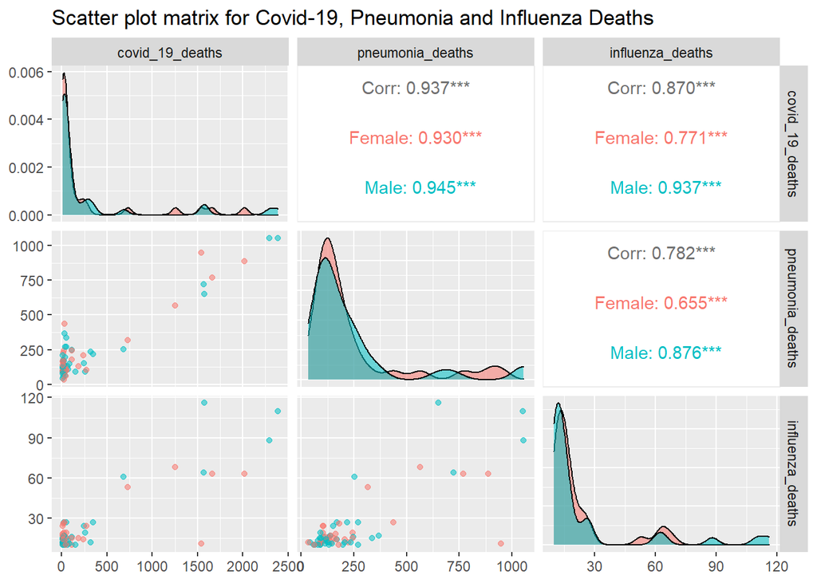

```r
selected_data_2 <- df2 %>%
  filter(group == "By Month",
         sex %in% c("Female", "Male"),
         age_group %in% age_group_names,
         state != "United States")  # Remove data stored
                                    # under United States (repeated values)

# Assign zero to missing values
selected_data_2$covid_19_deaths[is.na(selected_data_2$covid_19_deaths)] <- 0
selected_data_2$pneumonia_deaths[is.na(selected_data_2$pneumonia_deaths)] <- 0
selected_data_2$influenza_deaths[is.na(selected_data_2$influenza_deaths)] <- 0

selected_data_2 %>%
  filter(covid_19_deaths > 0, pneumonia_deaths > 0, influenza_deaths > 0) %>%
  mutate(age_group = as.factor(age_group),
         sex = as.factor(sex)) %>%
  ggpairs(mapping = aes(color=sex, alpha =0.2),
         columns =c ("covid_19_deaths", "pneumonia_deaths", "influenza_deaths"))+
   ggtitle("Scatter plot matrix for Covid-19, Pneumonia and Influenza Deaths")
```